# ST 495 HW2

Eric Warren

2022-09-01

## Honor Code

I have neither given nor received unauthorized assistance on this test or assignment. -**Eric Warren**

### Problem 1

#### Read in the data

Here we are going to read in the Iris data set

```r
library(tidyverse)
tibble(iris)
```

```
## # A tibble: 150 × 5
##    Sepal.Length Sepal.Width Petal.Length Petal.Width Species
##           <dbl>       <dbl>        <dbl>       <dbl> <fct>
##  1          5.1         3.5          1.4         0.2 setosa
##  2          4.9         3            1.4         0.2 setosa
##  3          4.7         3.2          1.3         0.2 setosa
##  4          4.6         3.1          1.5         0.2 setosa
##  5          5           3.6          1.4         0.2 setosa
##  6          5.4         3.9          1.7         0.4 setosa
##  7          4.6         3.4          1.4         0.3 setosa
##  8          5           3.4          1.5         0.2 setosa
##  9          4.4         2.9          1.4         0.2 setosa
## 10          4.9         3.1          1.5         0.1 setosa
## # … with 140 more rows
```

#### Part A

Here we are going to describe the iris data set.

```r
str(iris)
```

```
## 'data.frame':    150 obs. of  5 variables:
##  $ Sepal.Length: num  5.1 4.9 4.7 4.6 5 5.4 4.6 5 4.4 4.9 ...
##  $ Sepal.Width : num  3.5 3 3.2 3.1 3.6 3.9 3.4 3.4 2.9 3.1 ...
##  $ Petal.Length: num  1.4 1.4 1.3 1.5 1.4 1.7 1.4 1.5 1.4 1.5 ...
##  $ Petal.Width : num  0.2 0.2 0.2 0.2 0.2 0.4 0.3 0.2 0.2 0.1 ...
##  $ Species     : Factor w/ 3 levels "setosa","versicolor",..: 1 1 1 1 1 1 1 1 1 1 ...
```

The Iris data set includes 150 observations which includes 5 variables. The variable names are Sepal.Length, Sepal.Width, Petal.Length, Petal.Width, Species. The Iris data set gives the measurements of the variables sepal length and width along with the petal length and width in centimeters for 50 flowers from each of 3 species that exist. The three species are Setosa, Versicolor, and Virginica.

#### Part B

Here we are going to find the mean and standard deviations for all of the numeric columns for each species of Iris.

```r
summary <- iris %>%
  group_by(Species) %>%
  summarize_all(list(mean = mean, sd = sd))
summary
```

```
## # A tibble: 3 × 9
##   Species    Sepal.Length_me… Sepal.Width_mean Petal.Length_me… Petal.Width_mean
##   <fct>                 <dbl>            <dbl>            <dbl>            <dbl>
## 1 setosa                 5.01             3.43             1.46            0.246
## 2 versicolor             5.94             2.77             4.26            1.33
## 3 virginica              6.59             2.97             5.55            2.03
## # … with 4 more variables: Sepal.Length_sd <dbl>, Sepal.Width_sd <dbl>,
## #   Petal.Length_sd <dbl>, Petal.Width_sd <dbl>
```

In this matrix you can find the mean and standard deviations of the petal and sepal lengths and widths of each species.

#### Part C

##### Sepal comparison

Here we are going to create a scatterplot of the Sepal Length and Width of each species.

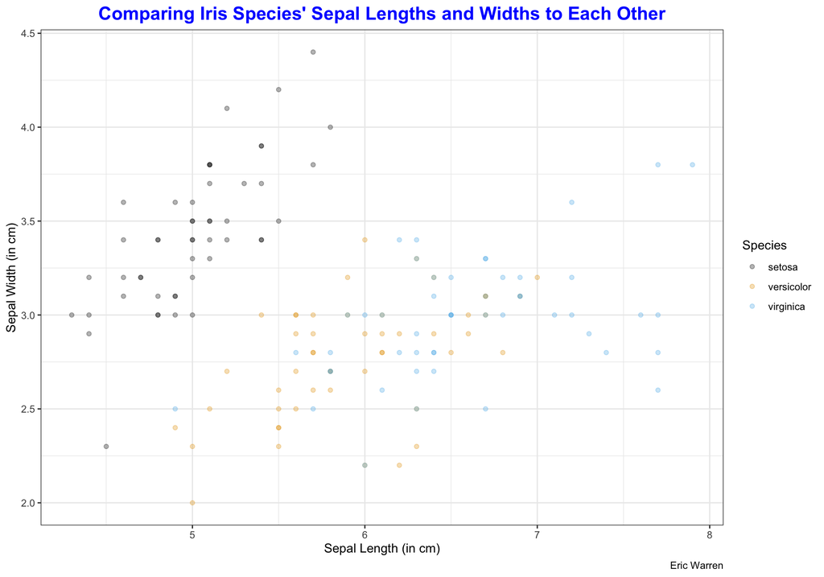

```r
iris %>%
  ggplot(aes(x = Sepal.Length,
             y = Sepal.Width,
             color = Species)) +
  geom_point(alpha = 0.3) +
  labs(title = "Comparing Iris Species' Sepal Lengths and Widths to Each Other",
       caption = "Eric Warren",
       x = "Sepal Length (in cm)",
       y = "Sepal Width (in cm)") +
  ggthemes::scale_color_colorblind() +
  theme_bw() +
  theme(plot.title = element_text(color = "blue",
                                  face = "bold",
                                  size = 16,
                                  hjust = 0.5))
```

From this scatterplot, we can see that the Setosa Iris stand out compared to the other two. This flower tends to have a smaller sepal length but a much bigger sepal width. The Versicolor and Virginica tend to have similar sepals, as the Virginica might have a bit longer length of its sepal.

##### Petal Comparison

Here we are going to create a scatterplot of the Petal Length and Width of each species.

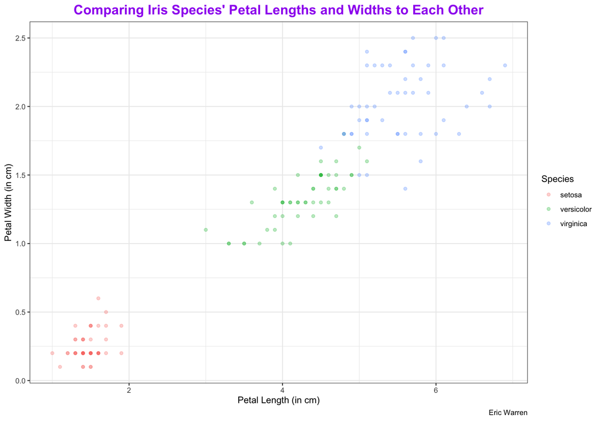

```r
iris %>%
  ggplot(aes(x = Petal.Length,
             y = Petal.Width,
             color = Species)) +
  geom_point(alpha = 0.3) +
  labs(title = "Comparing Iris Species' Petal Lengths and Widths to Each Other",
       caption = "Eric Warren",
       x = "Petal Length (in cm)",
       y = "Petal Width (in cm)") +
  theme_bw() +
  theme(plot.title = element_text(color = "purple",
                                  face = "bold",
                                  size = 16,
                                  hjust = 0.5))
```

You can seem to tell the Species of the Iris based on its petal features. The Setosa tends to have very small petal lengths and widths. The Versicolor and Virginica are again a bit similar but the Virginica tend to have a wider Petal than its Versicolor counterpart.

### NC Bike Crash Data

Here we are going to load in the NC Bike Crash data and use this to answer some questions about it.

```r
bicycleCrash <- read_csv("nc_bike_crash.csv")
```

#### Problem 2

Here we are going to construct a county-level summary of bike crashes, with the following information for each county: - Number of crashes - Average biker age - Maximum biker age - Average driver age - Maximum driver age

```r
# Make the crash summary matrix
crashSummary <- bicycleCrash %>%
  group_by(County) %>%
  summarize(numCrashes = n(),
            avgBikerAge = mean(Bike_Age, na.rm = T),
            maxBikerAge = max(Bike_Age, na.rm = T),
            avgDriverAge = mean(Drvr_Age, na.rm = T),
            maxDriverAge = max(Drvr_Age, na.rm = T)
            ) %>%
  filter(numCrashes >= 100) %>%
  arrange(desc(numCrashes))

# Load in the NC Population Data
pop2012 <- read_csv("nc population 2012.csv")
```

```
## ──────────────────────────────────────────────────────── Delimiter: "," chr
## (2): table with row headers in column A and column headers in rows 3 thr...
```

```r
colnames(pop2012) <- pop2012[1, ]
pop2012 <- pop2012[-1, ]

# Clean the Data to Merge Later
library(tm)
badThings = "County, North Carolina"
pop2012$County <- removeWords(pop2012$County, badThings)
pop2012$County <- substring(pop2012$County, 2)
pop2012$County <- trimws(pop2012$County)
pop2012$pop2012 <- as.numeric(gsub(",", "", pop2012$pop2012))
write_csv(pop2012, "nc population 2012 updated.csv")

# Merge them together
crashSummaryPop <- merge(crashSummary, pop2012, by = "County") %>%
  as_tibble()
crashSummaryPop
```

```
## # A tibble: 14 × 7
##    County   numCrashes avgBikerAge maxBikerAge avgDriverAge maxDriverAge pop2012
##    <chr>         <int>       <dbl>       <dbl>        <dbl>        <dbl>   <dbl>
##  1 Buncombe        157        29.3          69         39.5           70  243655
##  2 Cumberl…        221        31.9          67         39.3           70  329985
##  3 Durham          253        29.6          63         40.3           70  282659
##  4 Forsyth         123        32.6          69         40.0           70  357598
##  5 Gaston          113        27.5          69         38.1           70  207903
##  6 Guilford        384        30.1          69         37.0           70  500514
##  7 Mecklen…        695        31.8          69         39.2           70  967063
##  8 Nash            100        32.0          68         37.4           70   95187
##  9 New Han…        373        31.9          69         39.0           70  209045
## 10 Onslow          101        30.3          64         40.4           70  190678
## 11 Orange          139        31.2          65         39.0           70  137817
## 12 Pitt            109        29.9          65         38.7           70  172980
## 13 Robeson         105        36.5          65         40.8           70  135462
## 14 Wake            757        29.3          69         37.8           70  952060
```

There are 14 different counties in North Carolina that have had at least 100 different crashes. The table has their important features listed above.

#### Problem 3

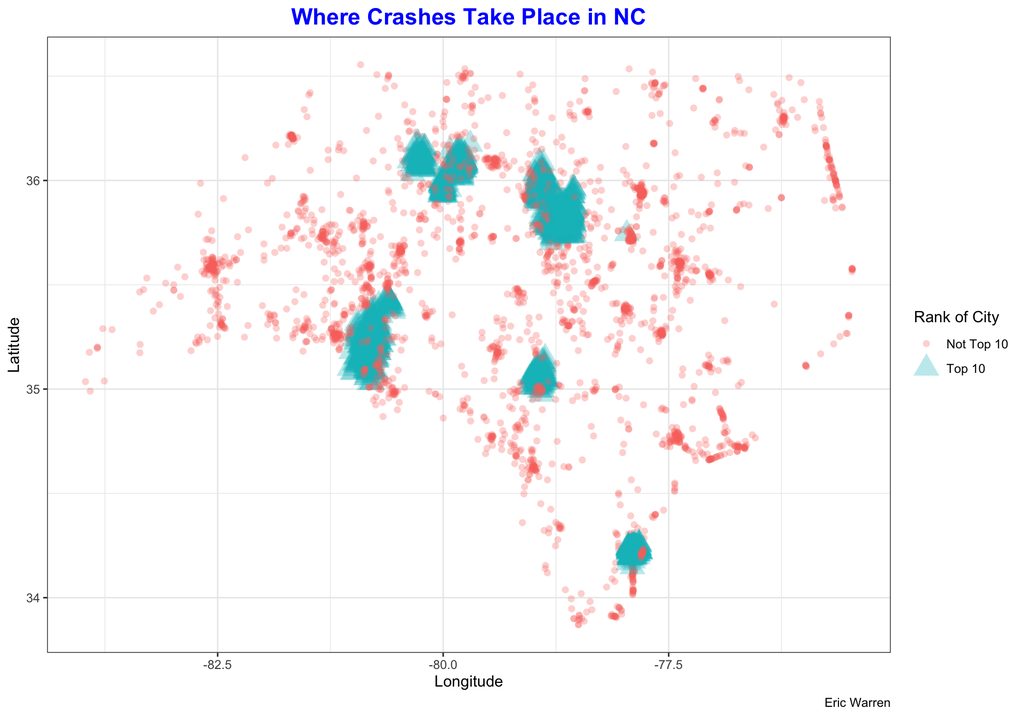

```r
# Find the top 10 most populous cities
popTop10 <- c("Charlotte",
              "Raleigh",
              "Greensboro",
              "Durham",
              "Winston-Salem",
              "Fayetteville",
              "Cary",
              "Wilmington",
              "High Point",
              "Concord")

# Now make new variable to show top 10
bicycleCrashTable <- as.data.frame(table(bicycleCrash$City))
colnames(bicycleCrashTable) <- c("City", "numCrashes")
bicycleCrashTable <- bicycleCrashTable %>%
  mutate(cityRank = ifelse(City %in% popTop10, "Top 10", "Not Top 10"))

# Get longitude and latitude
bicycleCrashLocation <- bicycleCrash %>%
  select(c(City,
           Location))
bicycleCrashInfo <- merge(bicycleCrashTable, bicycleCrashLocation, by = "City") %>%
  as_tibble() %>%
  select(-numCrashes)

a = bicycleCrashInfo$Location
a = as.character(a)
a = strsplit(a, ",")
a = unlist(a)
loc = matrix(as.numeric(a),
             nrow = nrow(bicycleCrashInfo),
             byrow = T)
loc = data.frame(loc)
names(loc) = c("latitude", "longitude")

bicycleCrashInfoUpdated <- cbind(bicycleCrashInfo, loc) %>%
  filter(latitude != 0,
         longitude != 0) %>%
  as_tibble() %>%
  select(-Location)

# Make scatterplot of crash locations
bicycleCrashInfoUpdated %>%
  ggplot(aes(x = longitude,
             y = latitude,
             color = cityRank)) +
  geom_point(aes(shape = cityRank,
                 size = cityRank),
             alpha = 0.3) +
  labs(title = "Where Crashes Take Place in NC",
       caption = "Eric Warren",
       x = "Longitude",
       y = "Latitude",
       color = "Rank of City",
       shape = "Rank of City",
       size = "Rank of City") +
  theme_bw() +
  theme(plot.title = element_text(color = "blue",
                                  face = "bold",
                                  size = 16,
                                  hjust = 0.5))
```

We can see that more of these crashes take place in areas with a larger population, which makes a lot of sense since there are more people. The plot also shows that the outer banks and some mountain areas are more dense for accidents as well and this also makes sense since there is a lot of travel to these areas for vacation.

#### Problem 4

Here we are going to construct box plots showing some features as it relates to injury levels.

##### Part A

Here we are going to construct a box plot of biker age for the different biker injury levels.

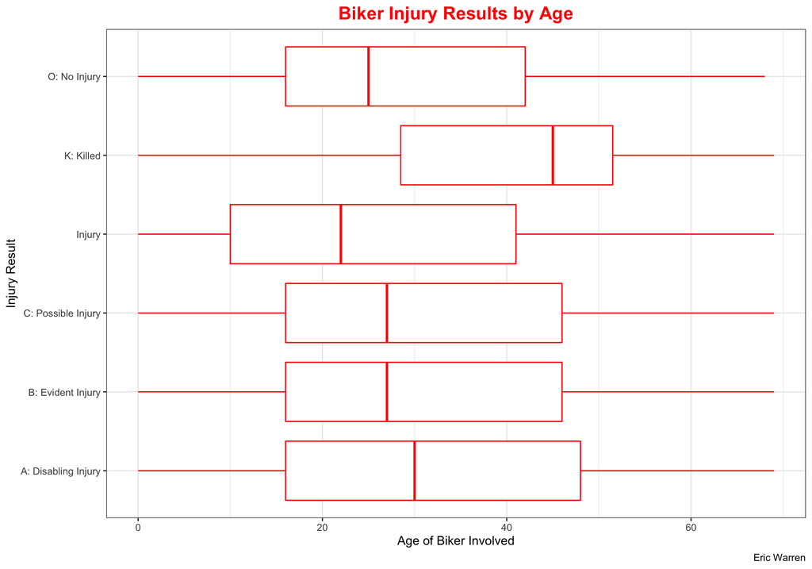

```r
bicycleCrash %>%
  ggplot(aes(x = Bike_Age,
             y = Bike_Injur)) +
  geom_boxplot(color = "red") +
  labs(title = "Biker Injury Results by Age",
       caption = "Eric Warren",
       x = "Age of Biker Involved",
       y = "Injury Result") +
  theme_bw() +
  theme(plot.title = element_text(color = "red",
                                  face = "bold",
                                  size = 16,
                                  hjust = 0.5))
```

The injury results are very similar by age, except for death. It seems that the older someone is in terms of their age as the biker, the more likely they could die from that accident.

##### Part B

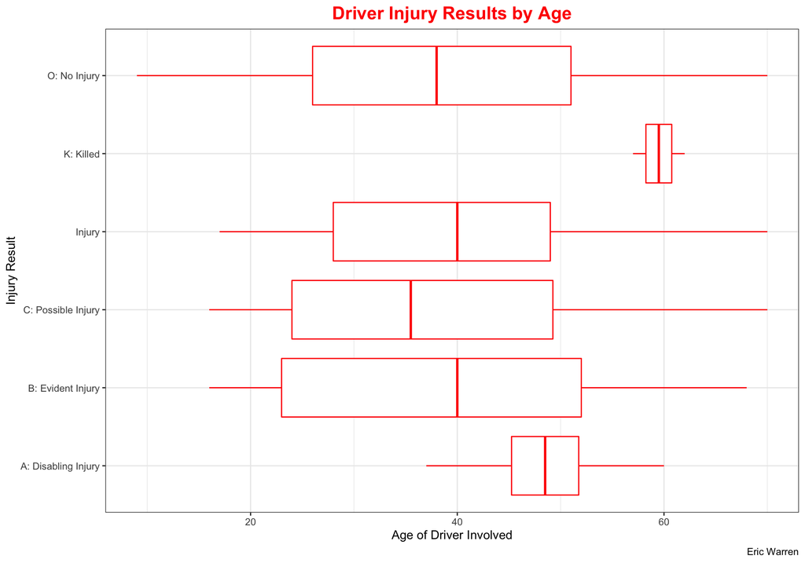

```r
bicycleCrash %>%
  ggplot(aes(x = Drvr_Age,
             y = Drvr_Injur)) +
  geom_boxplot(color = "red") +
  labs(title = "Driver Injury Results by Age",
       caption = "Eric Warren",
       x = "Age of Driver Involved",
       y = "Injury Result") +
  theme_bw() +
  theme(plot.title = element_text(color = "red",
                                  face = "bold",
                                  size = 16,
                                  hjust = 0.5))
```

The injury results are very similar by age, except for death and disabling injury. It seems that the older someone is in terms of their age as the driver, the more likely they could die from that accident or at the very least have a very serious injury. This could make sense since as you get older, your body is not as strong and cannot take the impact it did at a younger age.

#### Problem 5

Here we are going to make some bar plots to show how accidents results are based on speed.

##### Part A

Here we are going to construct a bar plot for speed limit.

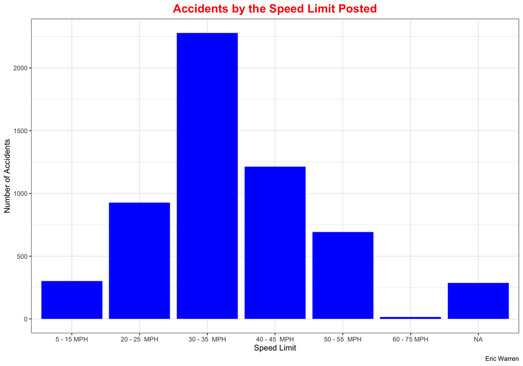

```r
bicycleCrash <- bicycleCrash %>%
  mutate(Speed_Limit = factor(Speed_Limi, c("5 - 15 MPH",
                                            "20 - 25  MPH",
                                            "30 - 35  MPH",
                                            "40 - 45  MPH",
                                            "50 - 55  MPH",
                                            "60 - 75 MPH")))
bicycleCrash %>%
  ggplot(aes(x = Speed_Limit)) +
  geom_bar(fill = "blue") +
  labs(title = "Accidents by the Speed Limit Posted",
       caption = "Eric Warren",
       x = "Speed Limit",
       y = "Number of Accidents") +
  theme_bw() +
  theme(plot.title = element_text(color = "red",
                                  face = "bold",
                                  size = 16,
                                  hjust = 0.5))
```

A lot of accidents happen in the 30-35 MPH zone. This might be because a lot of city speed limits are 35 MPH (the rule is 35 MPH unless otherwise posted) so since more roads are like this, you could have more accidents.

##### Part B

Here we are going to construct a stacked barplot for speed limit with stacks given by ambulance requirement.

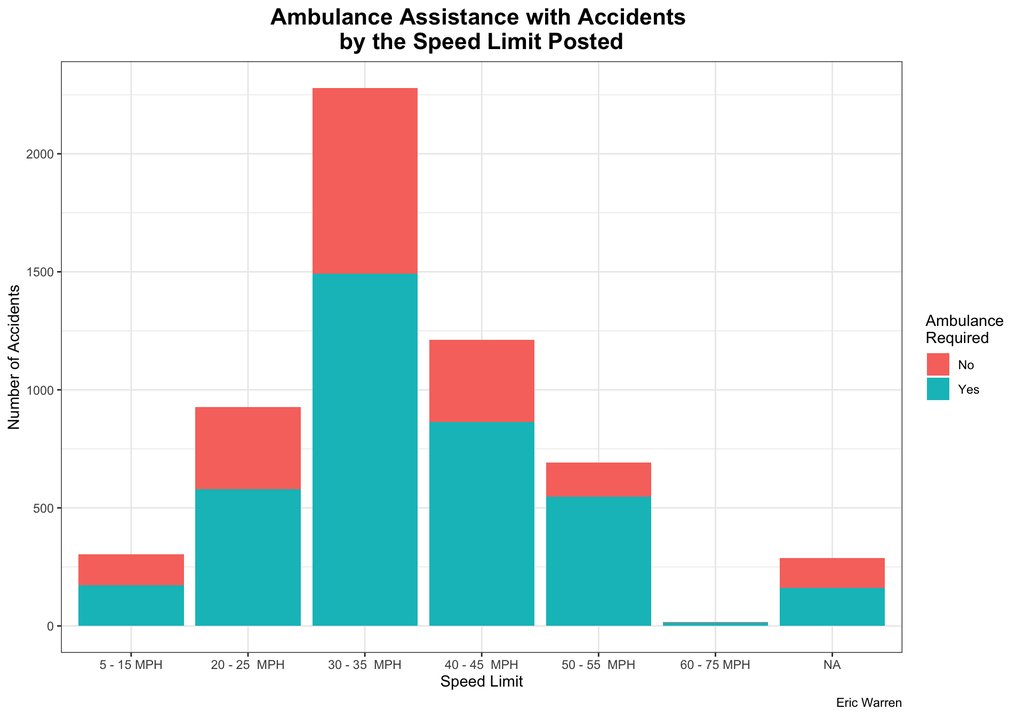

```r
bicycleCrash %>%
  ggplot(aes(x = Speed_Limit,
             fill = AmbulanceR)) +
  geom_bar() +
  labs(title = "Ambulance Assistance with Accidents \nby the Speed Limit Posted",
       caption = "Eric Warren",
       x = "Speed Limit",
       y = "Number of Accidents",
       fill = "Ambulance \nRequired") +
  theme_bw() +
  theme(plot.title = element_text(color = "black",
                                  face = "bold",
                                  size = 16,
                                  hjust = 0.5))
```

We can see that the ambulance is needed for a lot of the accidents but the higher the speed limit posted, the more likely it seems to be that the ambulance will be needed. This makes sense since the force will be much higher (`force = mass * acceleration`) and with a mostly constant mass, the faster velocity of cars will cause a faster acceleration and thus cause more of an impact on an accident.

### Problem 6

#### Part A

Here we are going to load in the uspopage data set.

```r
library(gcookbook)
usPopAge <- as_tibble(uspopage)
usPopAge
```

```
## # A tibble: 824 × 3
##     Year AgeGroup Thousands
##    <int> <fct>        <int>
##  1  1900 <5            9181
##  2  1900 5-14         16966
##  3  1900 15-24        14951
##  4  1900 25-34        12161
##  5  1900 35-44         9273
##  6  1900 45-54         6437
##  7  1900 55-64         4026
##  8  1900 >64           3099
##  9  1901 <5            9336
## 10  1901 5-14         17158
## # … with 814 more rows
```

For this data set, we can see the number of people in each age group for every year from 1900 until 2002. There are 8 different age groups, as specified as <5, 5-14, 15-24, 25-34, 35-44, 45-54, 55-64, >64. We can also see how the number of people in each age group is increasing over time.

#### Part B

Here we are going to construct a stacked area graph with Year in the x-axis, population (in thousands) in the y-axis, and different age groups in different layers.

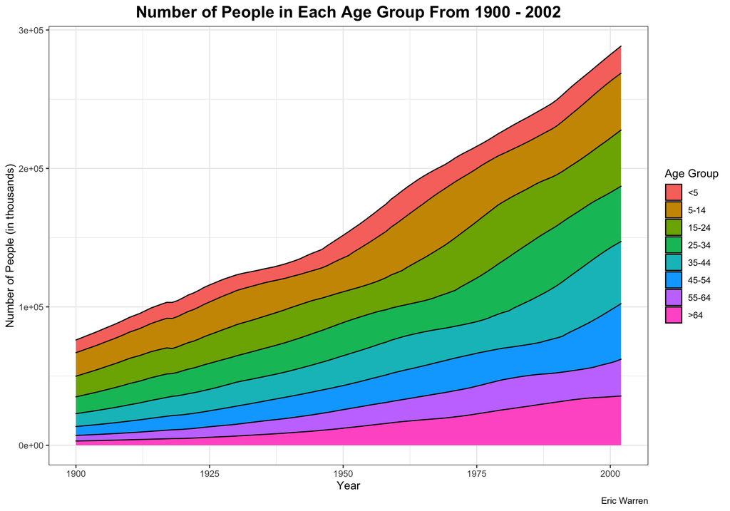

```r
usPopAge %>%
  ggplot(aes(x = Year,
           y = Thousands,
           fill = AgeGroup)) +
  geom_area(color = "black") +
  labs(title = "Number of People in Each Age Group From 1900 - 2002",
       caption = "Eric Warren",
       x = "Year",
       y = "Number of People (in thousands)",
       fill = "Age Group") +
  theme_bw() +
  theme(plot.title = element_text(color = "black",
                                  face = "bold",
                                  size = 16,
                                  hjust = 0.5))
```

We can see that the total number of people go up over time, but it seems that the >64 age group has gone up the most over time. We will examine if this is true soon.

#### Part C

Here we are going to construct a proportional stacked area graph for each Year, and compute the contribution from each age group to the total population as a fraction of the total population.

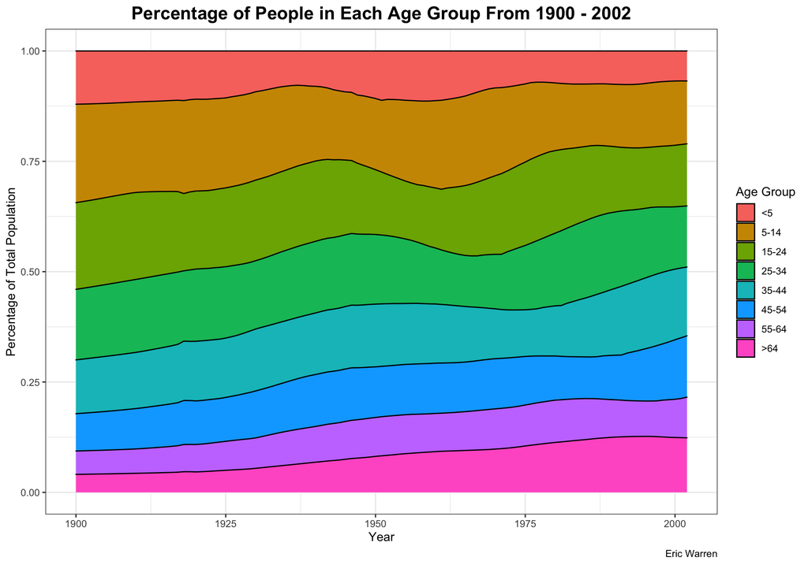

```r
# Get the proportions here
usPopAgeProportionTable <- usPopAge %>%
  group_by(Year) %>%
  summarize(totalPop = sum(Thousands)) %>%
  ungroup()
usPopAgeProportionTableUpdated <- do.call("rbind", replicate(8, usPopAgeProportionTable, simplify = FALSE)) %>%
  arrange(Year)
usPopAgeProportion <- as_tibble(unique(merge(usPopAge, usPopAgeProportionTableUpdated, by = "Year"))) %>%
  mutate(proportion = Thousands / totalPop)

# Make the graph with proportions
usPopAgeProportion %>%
  ggplot(aes(x = Year,
           y = proportion,
           fill = AgeGroup)) +
  geom_area(color = "black") +
  labs(title = "Percentage of People in Each Age Group From 1900 - 2002",
       caption = "Eric Warren",
       x = "Year",
       y = "Percentage of Total Population",
       fill = "Age Group") +
  theme_bw() +
  theme(plot.title = element_text(color = "black",
                                  face = "bold",
                                  size = 16,
                                  hjust = 0.5))
```

### Problem 7

#### Part A

Here we are going to load the faithful data set.

```r
faithful <- as_tibble(faithful)
faithful
```

```
## # A tibble: 272 × 2
##    eruptions waiting
##        <dbl>   <dbl>
##  1      3.6       79
##  2      1.8       54
##  3      3.33      74
##  4      2.28      62
##  5      4.53      85
##  6      2.88      55
##  7      4.7       88
##  8      3.6       85
##  9      1.95      51
## 10      4.35      85
## # … with 262 more rows
```

Here we get to see the amount of time in minutes that an eruption takes at Old Faithful Geyser and we also see the waiting time in minutes for the next eruption to take place. There are 272 observations and only the two variables I already mentioned.

#### Part B

Here we are going to construct a scatter plot with eruption time in the x-axis, and waiting time in the y-axis.

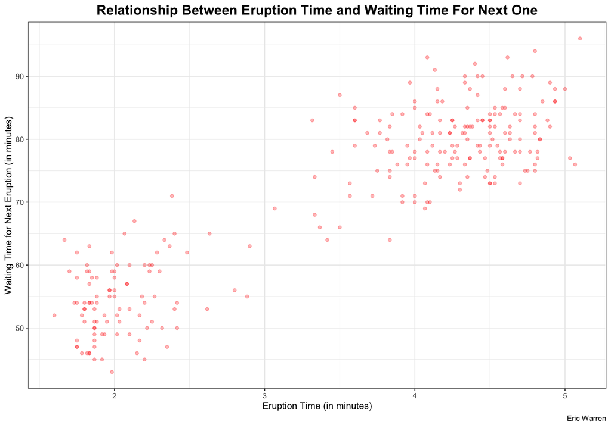

```r
faithful %>%
  ggplot(aes(x = eruptions,
             y = waiting)) +
  geom_point(alpha = 0.3,
             color = "red") +
  labs(title = "Relationship Between Eruption Time and Waiting Time For Next One",
       caption = "Eric Warren",
       x = "Eruption Time (in minutes)",
       y = "Waiting Time for Next Eruption (in minutes)") +
  theme_bw() +
  theme(plot.title = element_text(color = "black",
                                  face = "bold",
                                  size = 16,
                                  hjust = 0.5))
```

You can see a direct relationship between the amount of time an eruption takes and the waiting time for the next one. As the eruption time increases, the amount of waiting time before the next eruption also increases. It also seems that most eruptions take place in less than 3 minutes or 4 to 5 minutes, but not much outside of those ranges.